# Peer-graded Assignment: Course Project

Antonio Bulla

## Introduction

The National Survey on Drug Use and Health (NSDUH) series (formerly titled National Household Survey on Drug Abuse) primarily measures the prevalence and correlates of drug use in the United States. The surveys are designed to provide quarterly, as well as annual, estimates. Information is provided on the use of illicit drugs, alcohol, and tobacco among members of United States households aged 12 and older.

The application is running on: [https://databull.shinyapps.io/DrugUseByAge/About this project](https://databull.shinyapps.io/DrugUseByAge/About%20this%20project)

The Git repository: https://github.com/codebull80/DrugByAgeShiny

This project develop an interface to the 2012 data of National Survey on Drug Use and Health.It automatically downloads data from the fivethirtyeight github repository https://raw.githubusercontent.com/fivethirtyeight/data/master/drug-use-by-age/drug-use-by-age.csv Then it performs some manipulations to tidy the dataset.

Two categories are analysed:

- “Percentage of those in an age group who used each substance in the past 12 months”
- “Median number of times a user in an age group used each substance in the past 12 months”

## The interface

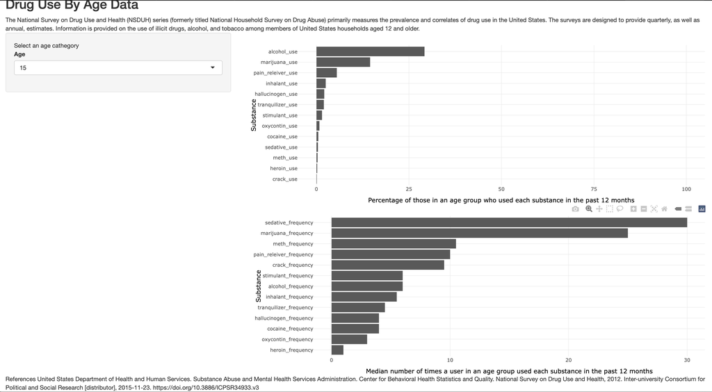

Just select the one age category to see the bar plots!

## Citation

United States Department of Health and Human Services. Substance Abuse and Mental Health Services Administration. Center for Behavioral Health Statistics and Quality. National Survey on Drug Use and Health, 2012. Interuniversity Consortium for Political and Social Research [distributor], 2015-11-23. https://doi.org/10.3886/ICPSR34933.v3